# Analysis of the U.S. National Oceanic and Atmospheric Administration’s (NOAA) storm database

EPriske

8 Oktober 2021

# Sypnosis

The objective from this analysis is to observe what Event type were the ones causing the most Injuries, Fatalities and property damage in USA. To be able to do this analysis we used the U.S. National Oceanic and Atmospheric Administration’s (NOAA) storm database.

This database tracks characteristics of major storms and weather events in the United States, including when and where they occur, as well as estimates of any fatalities, injuries, and property damage.

## Data loading and processing

# Required Libraries for the analysis

```r
library(dplyr)
library(ggplot2)
library(RColorBrewer)
library(lubridate)
library(gridExtra)
library(chron)
```

# Downloading the data.

First we check if we have the file already in our working directory. If not we download it.

```r
if(!file.exists("StormData")){
  fileURL <- "https://d396qusza40orc.cloudfront.net/repdata%2Fdata%2FStormData.csv.bz2"
  download.file(fileURL, "StormData")
  data <- read.csv('C:/Users/priskeer/Desktop/PilotTest24.02.2021/ProjectExtras/Privat/School/Data Science/Course 5/Week4/StormData', header=T)
  storm <- data
  storm <- data.frame(storm)
}

if(file.exists("StormData")){
  data <- read.csv('C:/Users/priskeer/Desktop/PilotTest24.02.2021/ProjectExtras/Privat/School/Data Science/Course 5/Week4/StormData', header=T)
  storm <- data
  storm <- data.frame(storm)
}
```

# Processing the Data

We want to analyse what Event type is responsable for the most injuries, fatalities and property damage, so the first step is to process the database.

We remove every variable we dont need for this analysis. The remaining variables we change them to a correctly class for our needs.

At the end we observe the summary from our remaining data.

```r
storm <- storm[-c(9:22, 26:37)]
storm$BGN_DATE <- as.character(storm$BGN_DATE)
storm$BGN_DATE <- as_date(mdy_hms(storm$BGN_DATE), tz=NULL)
storm$COUNTY <- as.factor(storm$COUNTY)
storm$STATE <- as.factor(storm$STATE)

head(storm)
```

```
##   STATE__   BGN_DATE BGN_TIME TIME_ZONE COUNTY COUNTYNAME STATE  EVTYPE
## 1       1 1950-04-18     0130       CST     97     MOBILE    AL TORNADO
## 2       1 1950-04-18     0145       CST      3    BALDWIN    AL TORNADO
## 3       1 1951-02-20     1600       CST     57    FAYETTE    AL TORNADO
## 4       1 1951-06-08     0900       CST     89    MADISON    AL TORNADO
## 5       1 1951-11-15     1500       CST     43    CULLMAN    AL TORNADO
## 6       1 1951-11-15     2000       CST     77 LAUDERDALE    AL TORNADO
##   FATALITIES INJURIES PROPDMG
## 1          0       15    25.0
## 2          0        0     2.5
## 3          0        2    25.0
## 4          0        2     2.5
## 5          0        2     2.5
## 6          0        6     2.5
```

```r
summary(storm)
```

```
##     STATE__        BGN_DATE                 BGN_TIME        TIME_ZONE
##  Min.   : 1.0   Min.   :1950-01-03   12:00:00 AM: 10163   CST    :547493
##  1st Qu.:19.0   1st Qu.:1995-04-20   06:00:00 PM:  7350   EST    :245558
##  Median :30.0   Median :2002-03-18   04:00:00 PM:  7261   MST    : 68390
##  Mean   :31.2   Mean   :1998-12-27   05:00:00 PM:  6891   PST    : 28302
##  3rd Qu.:45.0   3rd Qu.:2007-07-28   12:00:00 PM:  6703   AST    :  6360
##  Max.   :95.0   Max.   :2011-11-30   03:00:00 PM:  6700   HST    :  2563
##                                      (Other)    :857229   (Other):  3631
##      COUNTY            COUNTYNAME         STATE
##  1      : 17810   JEFFERSON :  7840   TX     : 83728
##  3      : 16220   WASHINGTON:  7603   KS     : 53440
##  19     : 14141   JACKSON   :  6660   OK     : 46802
##  15     : 13858   FRANKLIN  :  6256   MO     : 35648
##  5      : 13847   LINCOLN   :  5937   IA     : 31069
##  17     : 13081   MADISON   :  5632   NE     : 30271
##  (Other):813340   (Other)   :862369   (Other):621339
##                EVTYPE         FATALITIES          INJURIES
##  HAIL             :288661   Min.   :  0.0000   Min.   :   0.0000
##  TSTM WIND        :219940   1st Qu.:  0.0000   1st Qu.:   0.0000
##  THUNDERSTORM WIND: 82563   Median :  0.0000   Median :   0.0000
##  TORNADO          : 60652   Mean   :  0.0168   Mean   :   0.1557
##  FLASH FLOOD      : 54277   3rd Qu.:  0.0000   3rd Qu.:   0.0000
##  FLOOD            : 25326   Max.   :583.0000   Max.   :1700.0000
##  (Other)          :170878
##     PROPDMG
##  Min.   :   0.00
##  1st Qu.:   0.00
##  Median :   0.00
##  Mean   :  12.06
##  3rd Qu.:   0.50
##  Max.   :5000.00
##
```

```r
str(storm)
```

```
## 'data.frame':    902297 obs. of  11 variables:
##  $ STATE__   : num  1 1 1 1 1 1 1 1 1 1 ...
##  $ BGN_DATE  : Date, format: "1950-04-18" "1950-04-18" ...
##  $ BGN_TIME  : Factor w/ 3608 levels "00:00:00 AM",..: 272 287 2705 1683 2584 3186 242 1683 3186 3186 ...
##  $ TIME_ZONE : Factor w/ 22 levels "ADT","AKS","AST",..: 7 7 7 7 7 7 7 7 7 7 ...
##  $ COUNTY    : Factor w/ 557 levels "0","1","2","3",..: 98 4 58 90 44 78 10 124 126 58 ...
##  $ COUNTYNAME: Factor w/ 29601 levels "","5NM E OF MACKINAC BRIDGE TO PRESQUE ISLE LT MI",..: 13513 1873 4598 10592 4372 10094 1973 23873 24418 4598 ...
##  $ STATE     : Factor w/ 72 levels "AK","AL","AM",..: 2 2 2 2 2 2 2 2 2 2 ...
##  $ EVTYPE    : Factor w/ 985 levels "   HIGH SURF ADVISORY",..: 834 834 834 834 834 834 834 834 834 834 ...
##  $ FATALITIES: num  0 0 0 0 0 0 0 0 1 0 ...
##  $ INJURIES  : num  15 0 2 2 2 6 1 0 14 0 ...
##  $ PROPDMG   : num  25 2.5 25 2.5 2.5 2.5 2.5 2.5 25 25 ...
```

# What state has the most Events in USA?

First we aggregate the data by Event type and State and order it in descending order and then we plot it using ggplot2.

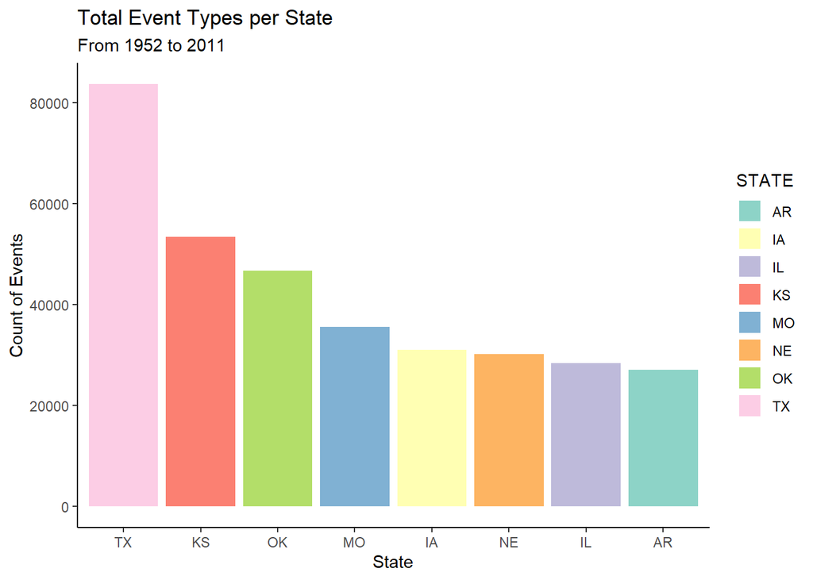

```r
EventState <- aggregate(EVTYPE ~ STATE, storm, FUN = length)
EventState %>%
  arrange(desc(EVTYPE)) %>%
  slice(1:8) %>%
  ggplot(aes(x = reorder(STATE, -EVTYPE), y = EVTYPE, fill = STATE)) +
  geom_col(size = 2) +
  labs(title = "Total Event Types per State", subtitle = "From 1952 to 2011") +
  ylab("Count of Events") +
  xlab("State") +
  theme_classic() +
  scale_fill_brewer(palette = "Set3")
```

# What event type is the most ocurring?

Here we summarize all the Events to know which one is the most recurring, then we sort them in descending order and we choose only the top 8 of the events. At the end we plot the data using ggplot2.

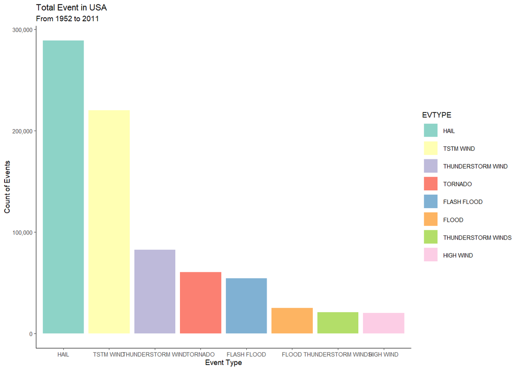

```r
EventT <- sort(table(storm$EVTYPE), decreasing = TRUE)
EventT <- EventT[1:8]
EventT <- data.frame(EventT)
colnames(EventT) <- c("EVTYPE", "Frequency")
EventT %>%
  ggplot(aes(x = EVTYPE, y = Frequency, fill = EVTYPE)) +
  geom_col(size = 2) +
  labs(title = "Total Event in USA", subtitle = "From 1952 to 2011") +
  scale_y_continuous(name="Count of Events", labels = scales::comma) +
  xlab("Event Type") +
  theme_classic(base_size = 7) +
  scale_fill_brewer(palette = "Set3")
```

Here we see that the most recurring event happening in the USA is Hail than TSTM wind. Tornado takes the 4th place.

# Fatalities, Injuries, Property Damage per Event type

We want to know which event causes the most injuries and Fatalities and Property Damage.

First we summarise and create a new Data frame for each of the variables to analyse.

```r
#We want to know which event causes the most injuries and Fatalities and Property Damage.
#First we summarise and create a new Data frame with the new data.
EventDMG <- data.frame(storm[8:11])
EventDMG <- EventDMG %>%
              group_by(EVTYPE) %>%
              summarise(
                FATALITIES = sum(FATALITIES),
                INJURIES = sum(INJURIES),
                PROPDMG = sum(PROPDMG)

  )

#Top 8 from Event Type ordered by Fatalities
EventF <- EventDMG[1:2]
EventF <- EventF[order(EventF$FATALITIES, decreasing = TRUE),]
EventF <- EventF[1:8,]

#Top 8 from Event Type ordered by Injuries
EventI <- select(EventDMG, 1, 3)
EventI <- EventI[order(EventI$INJURIES, decreasing = TRUE),]
EventI <- EventI[1:8,]

#Top 8 from Event Type ordered by Property Damage
EventP <- select(EventDMG, 1, 4)
EventP <- EventP[order(EventP$PROPDMG, decreasing = TRUE),]
EventP <- EventP[1:8,]
```

Now we want to plot this information with the top 8 from every Variable

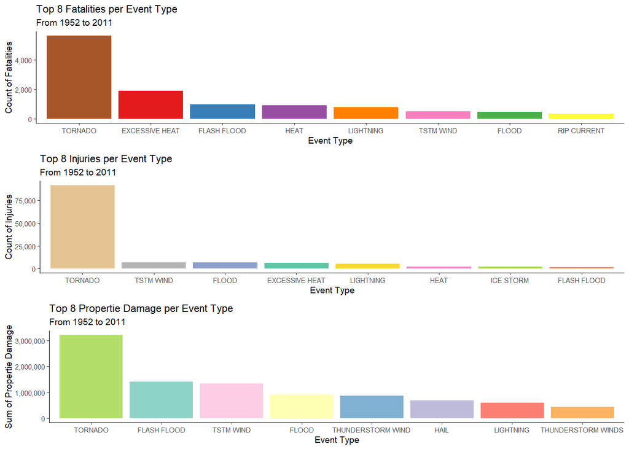

```r
require(gridExtra)

plot1 <- EventF %>%
  ggplot(aes(x = reorder(EVTYPE, -FATALITIES), y = FATALITIES, fill = EVTYPE)) +
  geom_col(size = 2) +
  labs(title = "Top 8 Fatalities per Event Type", subtitle = "From 1952 to 2011") +
  scale_y_continuous(name="Count of Fatalities", labels = scales::comma) +
  xlab("Event Type") +
  theme_classic(base_size = 7) +
  scale_fill_brewer(palette = "Set1") +
  guides(fill="none")

plot2 <- EventI %>%
  ggplot(aes(x = reorder(EVTYPE, -INJURIES), y = INJURIES, fill = EVTYPE)) +
  geom_col(size = 2) +
  labs(title = "Top 8 Injuries per Event Type", subtitle = "From 1952 to 2011") +
  scale_y_continuous(name="Count of Injuries", labels = scales::comma) +
  xlab("Event Type") +
  theme_classic(base_size = 7) +
  scale_fill_brewer(palette = "Set2") +
  guides(fill="none")

plot3 <- EventP %>%
  ggplot(aes(x = reorder(EVTYPE, -PROPDMG), y = PROPDMG, fill = EVTYPE)) +
  geom_col(size = 2) +
  labs(title = "Top 8 Propertie Damage per Event Type", subtitle = "From 1952 to 2011") +
  scale_y_continuous(name="Sum of Propertie Damage", labels = scales::comma) +
  xlab("Event Type") +
  theme_classic(base_size = 7) +
  scale_fill_brewer(palette = "Set3") +
  guides(fill="none")

grid.arrange(plot1, plot2, plot3, nrow=3)
```

```r
head(EventF)
```

```
## # A tibble: 6 x 2
##   EVTYPE         FATALITIES
##   <fct>               <dbl>
## 1 TORNADO              5633
## 2 EXCESSIVE HEAT       1903
## 3 FLASH FLOOD           978
## 4 HEAT                  937
## 5 LIGHTNING             816
## 6 TSTM WIND             504
```

```r
head(EventI)
```

```
## # A tibble: 6 x 2
##   EVTYPE         INJURIES
##   <fct>             <dbl>
## 1 TORNADO           91346
## 2 TSTM WIND          6957
## 3 FLOOD              6789
## 4 EXCESSIVE HEAT     6525
## 5 LIGHTNING          5230
## 6 HEAT               2100
```

```r
head(EventP)
```

```
## # A tibble: 6 x 2
##   EVTYPE             PROPDMG
##   <fct>                <dbl>
## 1 TORNADO           3212258.
## 2 FLASH FLOOD       1420125.
## 3 TSTM WIND         1335966.
## 4 FLOOD              899938.
## 5 THUNDERSTORM WIND  876844.
## 6 HAIL               688693.
```

Here we find out that Tornado is the event type that cause the most Damage, Injuries and Fatalities.